# Case Study 2 - Talent Attrition and Income

# Numerical Explanatory Variables EDA

There is a degree of correlation between Total Working Years and Monthly Income of .78, and Total Working Years and Age, however we will continue to explore these variables. Most of the numerical explanatory variables have a right skew, and are not overly linearly related.

We do see that TotaWorkingYears, PercentSalaryHike, YearsAtCompany, YearsInCurrentRoll, YearsSinceLastPromotion, MonthlyIncome, monthlyhours are heavily right skewed. We log2 transform these variables for our analysis. We tested our models with a log2 transformation on these variables, but did not see any increase in model performance, and abandoned the transformations.

When looking at the overlap of density, monthly hours, training time last year, and years since last promotion do not seem to uniquely identify individuals who might attrition, however may still be used to identify individuals in the model. More exploration is needed.

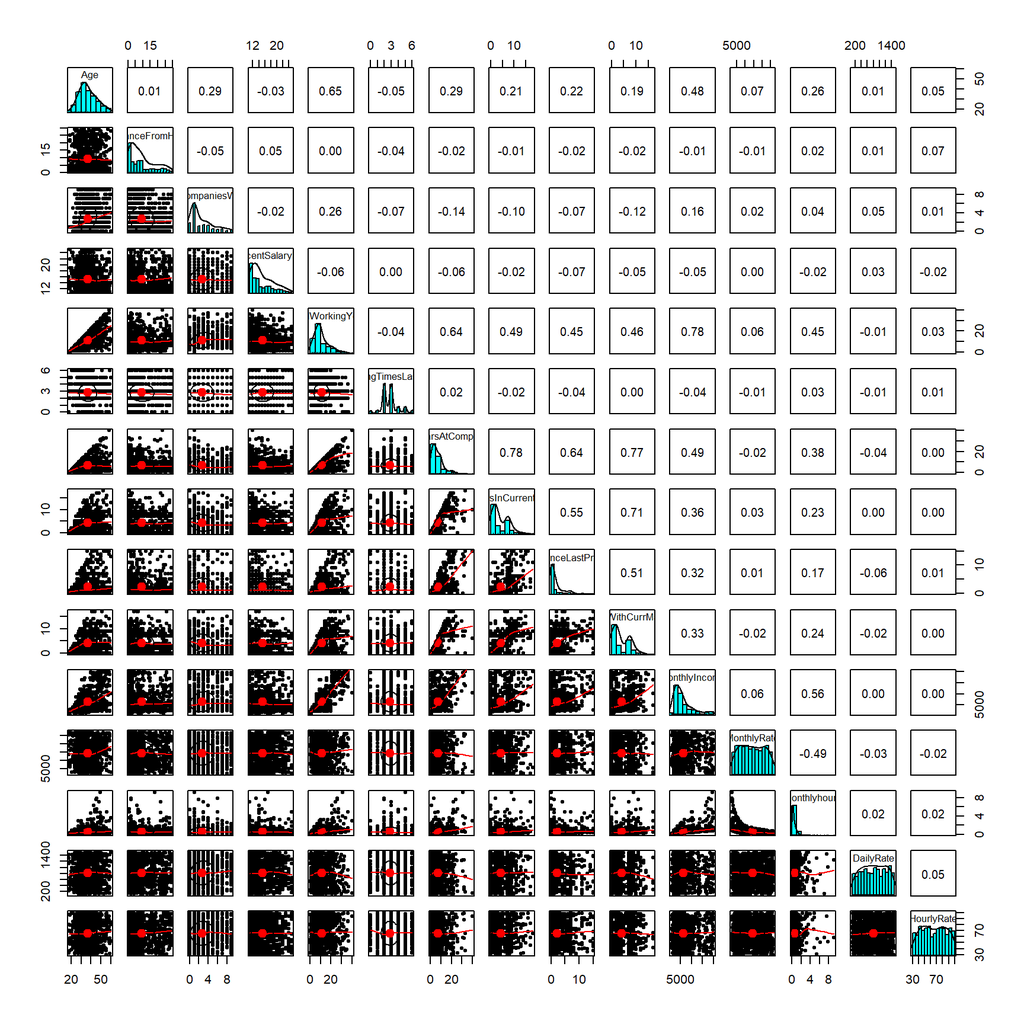

```r
# sorting the columns so that Atrrition column is first
talentcleanedDF <- talentcleanedDF %>% select("ID", "Attrition", everything())


corvars = c("Age", "DistanceFromHome", "NumCompaniesWorked", "PercentSalaryHike", "TotalWorkingYears", "TrainingTimesLastYear", "YearsAtCompany", "YearsInCurrentRole", "YearsSinceLastPromotion", "YearsWithCurrManager", "MonthlyIncome", "MonthlyRate", "monthlyhours", "DailyRate", "HourlyRate")


# check for correlation of numerical independent variables
pairs.panels(talentcleanedDF[,corvars])
```

```r
# transformin heavily right skewed variables

# colstolog <- c("TotalWorkingYears", "PercentSalaryHike", "YearsAtCompany", "YearsInCurrentRole", "YearsSinceLastPromotion", "MonthlyIncome", "monthlyhours", "DistanceFromHome")
#
# for (col in colstolog)
# {
#   talentcleanedDF[col] <- log(talentcleanedDF[col] + 1,2)
# }
```

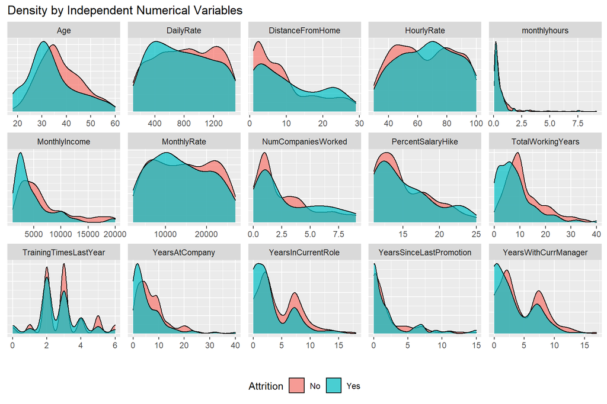

```r
# reviewing the density of each numerical variable by attrition
talent_reshaped <- data.frame(Attrition = talentcleanedDF$Attrition,independent.variable = c(talentcleanedDF$Age,talentcleanedDF$DistanceFromHome,talentcleanedDF$NumCompaniesWorked,talentcleanedDF$PercentSalaryHike, talentcleanedDF$TotalWorkingYears, talentcleanedDF$TrainingTimesLastYear, talentcleanedDF$YearsAtCompany, talentcleanedDF$YearsInCurrentRole, talentcleanedDF$YearsSinceLastPromotion, talentcleanedDF$YearsWithCurrManager, talentcleanedDF$MonthlyIncome, talentcleanedDF$MonthlyRate, talentcleanedDF$monthlyhours, talentcleanedDF$DailyRate, talentcleanedDF$HourlyRate),
Variable.name = rep(corvars,each=nrow(talentcleanedDF)))

ggplot(talent_reshaped,aes(independent.variable,fill=Attrition)) +
geom_density(alpha=.7, color='black') + facet_wrap(~Variable.name,scales="free", ncol = 5) +
xlab("") + theme(legend.position='bottom') + theme(axis.title.y=element_blank(),
        axis.text.y=element_blank(), axis.ticks.y=element_blank()) + ggtitle("Density by Independent Numerical Variables")
```

# Factor Analysis:

```r
# convert categorical variables to factors
names <- c("WorkLifeBalance", "StockOptionLevel", "RelationshipSatisfaction", "PerformanceRating", "OverTime", "MaritalStatus", "JobSatisfaction", "JobLevel", "JobInvolvement", "Gender", "EnvironmentSatisfaction", "BusinessTravel", "Attrition", "Education", "Department", "EducationField", "JobRole")


# set the categorical columns to factor
for (name in names)
{
  talentcleanedDF[,name]<-factor(talentcleanedDF[,name])
}

# convert factors to numeric for factor analysis
talentcleanedASNUMDF <- talentcleanedDF[,names] %>% mutate_all(as.numeric)

# adding suffix ASNUM to numerical representation of factors columns
colnames(talentcleanedASNUMDF) <- paste(colnames(talentcleanedASNUMDF), "ASNUM", sep = "_")

# adding numerical factor columns to base Df in order to perform stepwise for variable selection
talentcleanedwnumDF <- cbind(talentcleanedDF, talentcleanedASNUMDF)

# dropping factor columns
talentcleanedwnumDF <- talentcleanedwnumDF[, sapply(talentcleanedwnumDF, class) != "factor"]

#  columns for anova factor analysis
anovacols <- c(colnames(talentcleanedASNUMDF))
anovacols <- anovacols[anovacols != "Attrition_ASNUM"]

#  creating the formula to pass into aov function
anovafmla <- as.formula(paste("Attrition_ASNUM ~ ", paste(anovacols, collapse= "+")))

anova_fit <- aov(anovafmla, data=talentcleanedwnumDF)

summary(anova_fit)
```

```
##                                 Df Sum Sq Mean Sq F value   Pr(>F)
## WorkLifeBalance_ASNUM            1   0.95   0.947   8.659  0.00334 **
## StockOptionLevel_ASNUM           1   2.46   2.457  22.464 2.51e-06 ***
## RelationshipSatisfaction_ASNUM   1   0.20   0.201   1.841  0.17525
## PerformanceRating_ASNUM          1   0.02   0.020   0.183  0.66880
## OverTime_ASNUM                   1   8.69   8.686  79.419  < 2e-16 ***
## MaritalStatus_ASNUM              1   2.11   2.109  19.285 1.27e-05 ***
## JobSatisfaction_ASNUM            1   1.94   1.941  17.748 2.79e-05 ***
## JobLevel_ASNUM                   1   2.50   2.502  22.879 2.03e-06 ***
## JobInvolvement_ASNUM             1   3.48   3.475  31.773 2.36e-08 ***
## Gender_ASNUM                     1   0.13   0.129   1.182  0.27721
## EnvironmentSatisfaction_ASNUM    1   0.85   0.849   7.763  0.00545 **
## BusinessTravel_ASNUM             1   0.03   0.034   0.313  0.57596
## Education_ASNUM                  1   0.03   0.029   0.265  0.60707
## Department_ASNUM                 1   0.74   0.745   6.810  0.00922 **
## EducationField_ASNUM             1   0.04   0.041   0.379  0.53822
## JobRole_ASNUM                    1   0.01   0.010   0.091  0.76291
## Residuals                      853  93.29   0.109
## ---
## Signif. codes:  0 '***' 0.001 '**' 0.01 '*' 0.05 '.' 0.1 ' ' 1
```

## Modeling and Optimization

Variable selection using forward, backward, and stepwise. We have converted all factorial columns to numerical to proceed. Upon initial review of variable impacts in the model, we have determined that at a minium we would like to include the following (as this selection is preliminary, these are most likely to change):

- DistanceFromHome
- EnvironmentSatisfaction
- JobInvolvement
- JobSatisfaction
- MaritalStatus
- NumCompaniesWorked
- OverTime
- StockOptionLevel
- YearsSinceLastPromotion

Additionally, we would like to further investigate the following variables:

- Age
- Department
- JobLevel
- RelationshipSatisfaction
- WorkLifeBalance
- YearsInCurrentRole
- YearsWithCurrManager
- DailyRate
- MonthlyIncome
- HourlyRate
- PercentSalaryHike
- MonthlyRate
- monthlyhours

And we will premilinarily be moving forward without the following variables, as they statistically ignisificant:

- PerformanceRating
- BusinessTravel
- Education
- EducationField
- Gender
- JobRole
- TotalWorkingYears
- TrainingTimesLastYear
- YearsAtCompany

```r
# creating my own not in operator
`%notin%` <- Negate(`%in%`)

# remove ID and attrition from col list to build formula
#  columns for anova factor analysis
lmcols <- c(colnames(talentcleanedwnumDF))
lmcols <- lmcols[lmcols %notin% c("Attrition_ASNUM","ID")]
lmfmla <- as.formula(paste("Attrition_ASNUM ~ ", paste(lmcols, collapse= "+")))

#define intercept-only model
intercept_only_model <- lm(Attrition_ASNUM ~ 1, data = talentcleanedwnumDF)

#define total model
total_model <- lm(lmfmla, data = talentcleanedwnumDF)

# set the different models
talent_back_model <- step(total_model,
                          direction = "backward", trace=FALSE)

talent_step_model <- step(intercept_only_model,
                          direction = "both", scope = formula(total_model), trace=FALSE)

talent_fwd_model <- step(intercept_only_model,
                         direction = "forward", scope = formula(total_model), trace=FALSE)

summary(talent_back_model)
```

```
##
## Call:
## lm(formula = Attrition_ASNUM ~ Age + DistanceFromHome + NumCompaniesWorked +
##     TotalWorkingYears + TrainingTimesLastYear + YearsAtCompany +
##     YearsInCurrentRole + YearsSinceLastPromotion + YearsWithCurrManager +
##     WorkLifeBalance_ASNUM + RelationshipSatisfaction_ASNUM +
##     OverTime_ASNUM + MaritalStatus_ASNUM + JobSatisfaction_ASNUM +
##     JobLevel_ASNUM + JobInvolvement_ASNUM + EnvironmentSatisfaction_ASNUM +
##     Department_ASNUM, data = talentcleanedwnumDF)
##
## Residuals:
##      Min       1Q   Median       3Q      Max
## -0.56003 -0.20627 -0.08333  0.07407  1.09269
##
## Coefficients:
##                                 Estimate Std. Error t value Pr(>|t|)
## (Intercept)                     1.403513   0.119362  11.759  < 2e-16 ***
## Age                            -0.003530   0.001673  -2.110 0.035137 *
## DistanceFromHome                0.003630   0.001355   2.679 0.007517 **
## NumCompaniesWorked              0.017602   0.005002   3.519 0.000457 ***
## TotalWorkingYears              -0.004767   0.003258  -1.463 0.143716
## TrainingTimesLastYear          -0.015874   0.008692  -1.826 0.068168 .
## YearsAtCompany                  0.006103   0.004071   1.499 0.134234
## YearsInCurrentRole             -0.010838   0.005057  -2.143 0.032367 *
## YearsSinceLastPromotion         0.016480   0.004561   3.613 0.000321 ***
## YearsWithCurrManager           -0.010177   0.004990  -2.039 0.041736 *
## WorkLifeBalance_ASNUM          -0.038698   0.015521  -2.493 0.012849 *
## RelationshipSatisfaction_ASNUM -0.021357   0.009989  -2.138 0.032790 *
## OverTime_ASNUM                  0.209156   0.024294   8.609  < 2e-16 ***
## MaritalStatus_ASNUM             0.085847   0.015353   5.592 3.03e-08 ***
## JobSatisfaction_ASNUM          -0.045911   0.009927  -4.625 4.33e-06 ***
## JobLevel_ASNUM                 -0.028216   0.016541  -1.706 0.088412 .
## JobInvolvement_ASNUM           -0.083035   0.015709  -5.286 1.59e-07 ***
## EnvironmentSatisfaction_ASNUM  -0.027435   0.010056  -2.728 0.006499 **
## Department_ASNUM                0.048850   0.021264   2.297 0.021839 *
## ---
## Signif. codes:  0 '***' 0.001 '**' 0.01 '*' 0.05 '.' 0.1 ' ' 1
##
## Residual standard error: 0.3221 on 851 degrees of freedom
## Multiple R-squared:  0.2482, Adjusted R-squared:  0.2323
## F-statistic: 15.61 on 18 and 851 DF,  p-value: < 2.2e-16
```

```r
summary(talent_step_model)
```

```
##
## Call:
## lm(formula = Attrition_ASNUM ~ OverTime_ASNUM + MaritalStatus_ASNUM +
##     JobInvolvement_ASNUM + JobSatisfaction_ASNUM + NumCompaniesWorked +
##     YearsSinceLastPromotion + EnvironmentSatisfaction_ASNUM +
##     YearsInCurrentRole + DistanceFromHome + WorkLifeBalance_ASNUM +
##     RelationshipSatisfaction_ASNUM + Age + Department_ASNUM +
##     TrainingTimesLastYear + JobLevel_ASNUM + YearsWithCurrManager,
##     data = talentcleanedwnumDF)
##
## Residuals:
##      Min       1Q   Median       3Q      Max
## -0.56216 -0.20645 -0.08458  0.06818  1.12148
##
## Coefficients:
##                                 Estimate Std. Error t value Pr(>|t|)
## (Intercept)                     1.429625   0.118151  12.100  < 2e-16 ***
## OverTime_ASNUM                  0.210756   0.024296   8.674  < 2e-16 ***
## MaritalStatus_ASNUM             0.085465   0.015363   5.563 3.55e-08 ***
## JobInvolvement_ASNUM           -0.084542   0.015665  -5.397 8.79e-08 ***
## JobSatisfaction_ASNUM          -0.044580   0.009902  -4.502 7.66e-06 ***
## NumCompaniesWorked              0.014445   0.004692   3.079  0.00215 **
## YearsSinceLastPromotion         0.017651   0.004272   4.132 3.96e-05 ***
## EnvironmentSatisfaction_ASNUM  -0.027260   0.010050  -2.713  0.00681 **
## YearsInCurrentRole             -0.008540   0.004591  -1.860  0.06322 .
## DistanceFromHome                0.003538   0.001355   2.612  0.00916 **
## WorkLifeBalance_ASNUM          -0.039062   0.015526  -2.516  0.01205 *
## RelationshipSatisfaction_ASNUM -0.020183   0.009975  -2.023  0.04335 *
## Age                            -0.004560   0.001471  -3.101  0.00199 **
## Department_ASNUM                0.050487   0.021026   2.401  0.01656 *
## TrainingTimesLastYear          -0.015066   0.008669  -1.738  0.08260 .
## JobLevel_ASNUM                 -0.038194   0.012472  -3.062  0.00226 **
## YearsWithCurrManager           -0.007805   0.004502  -1.733  0.08337 .
## ---
## Signif. codes:  0 '***' 0.001 '**' 0.01 '*' 0.05 '.' 0.1 ' ' 1
##
## Residual standard error: 0.3224 on 853 degrees of freedom
## Multiple R-squared:  0.2452, Adjusted R-squared:  0.2311
## F-statistic: 17.32 on 16 and 853 DF,  p-value: < 2.2e-16
```

```r
summary(talent_fwd_model)
```

```
##
## Call:
## lm(formula = Attrition_ASNUM ~ OverTime_ASNUM + MaritalStatus_ASNUM +
##     JobInvolvement_ASNUM + TotalWorkingYears + JobSatisfaction_ASNUM +
##     NumCompaniesWorked + YearsSinceLastPromotion + EnvironmentSatisfaction_ASNUM +
##     YearsInCurrentRole + DistanceFromHome + WorkLifeBalance_ASNUM +
##     RelationshipSatisfaction_ASNUM + Age + Department_ASNUM +
##     TrainingTimesLastYear + JobLevel_ASNUM + YearsWithCurrManager +
##     YearsAtCompany, data = talentcleanedwnumDF)
##
## Residuals:
##      Min       1Q   Median       3Q      Max
## -0.56003 -0.20627 -0.08333  0.07407  1.09269
##
## Coefficients:
##                                 Estimate Std. Error t value Pr(>|t|)
## (Intercept)                     1.403513   0.119362  11.759  < 2e-16 ***
## OverTime_ASNUM                  0.209156   0.024294   8.609  < 2e-16 ***
## MaritalStatus_ASNUM             0.085847   0.015353   5.592 3.03e-08 ***
## JobInvolvement_ASNUM           -0.083035   0.015709  -5.286 1.59e-07 ***
## TotalWorkingYears              -0.004767   0.003258  -1.463 0.143716
## JobSatisfaction_ASNUM          -0.045911   0.009927  -4.625 4.33e-06 ***
## NumCompaniesWorked              0.017602   0.005002   3.519 0.000457 ***
## YearsSinceLastPromotion         0.016480   0.004561   3.613 0.000321 ***
## EnvironmentSatisfaction_ASNUM  -0.027435   0.010056  -2.728 0.006499 **
## YearsInCurrentRole             -0.010838   0.005057  -2.143 0.032367 *
## DistanceFromHome                0.003630   0.001355   2.679 0.007517 **
## WorkLifeBalance_ASNUM          -0.038698   0.015521  -2.493 0.012849 *
## RelationshipSatisfaction_ASNUM -0.021357   0.009989  -2.138 0.032790 *
## Age                            -0.003530   0.001673  -2.110 0.035137 *
## Department_ASNUM                0.048850   0.021264   2.297 0.021839 *
## TrainingTimesLastYear          -0.015874   0.008692  -1.826 0.068168 .
## JobLevel_ASNUM                 -0.028216   0.016541  -1.706 0.088412 .
## YearsWithCurrManager           -0.010177   0.004990  -2.039 0.041736 *
## YearsAtCompany                  0.006103   0.004071   1.499 0.134234
## ---
## Signif. codes:  0 '***' 0.001 '**' 0.01 '*' 0.05 '.' 0.1 ' ' 1
##
## Residual standard error: 0.3221 on 851 degrees of freedom
## Multiple R-squared:  0.2482, Adjusted R-squared:  0.2323
## F-statistic: 15.61 on 18 and 851 DF,  p-value: < 2.2e-16
```

# Further Refining the Model

```r
# remove ID and attrition from col list to build formula columns for anova factor analysis
mincols <- c("DistanceFromHome","EnvironmentSatisfaction_ASNUM","JobInvolvement_ASNUM","JobSatisfaction_ASNUM","MaritalStatus_ASNUM","NumCompaniesWorked","OverTime_ASNUM","StockOptionLevel_ASNUM","YearsSinceLastPromotion")

mincols <- mincols[mincols %notin% c("Attrition_ASNUM","ID")]
minfmla <- as.formula(paste("Attrition_ASNUM ~ ", paste(mincols, collapse= "+")))

#define minimum model
min_model <- lm(minfmla, data = talentcleanedwnumDF)

# additional columns to review
addcols <- c("Age","Department_ASNUM","JobLevel_ASNUM","RelationshipSatisfaction_ASNUM","WorkLifeBalance_ASNUM","YearsInCurrentRole","YearsWithCurrManager","DailyRate","MonthlyIncome","HourlyRate","PercentSalaryHike","MonthlyRate","monthlyhours")

allcols <- c(mincols, addcols)
allfmla <- as.formula(paste("Attrition_ASNUM ~ ", paste(allcols, collapse= "+")))

#define total model
total_model <- lm(allfmla, data = talentcleanedwnumDF)

# set the different models
talent_back_new_model <- step(total_model,
                          direction = "backward", scope = c(min_model,total_model), trace=FALSE)

talent_step_new_model <- step(min_model,
                          direction = "both", scope = c(min_model,total_model), trace=FALSE)

talent_fwd_new_model <- step(min_model,
                         direction = "forward", scope = c(min_model,total_model), trace=FALSE)

summary(talent_back_new_model)
```

```
##
## Call:
## lm(formula = Attrition_ASNUM ~ DistanceFromHome + EnvironmentSatisfaction_ASNUM +
##     JobInvolvement_ASNUM + JobSatisfaction_ASNUM + MaritalStatus_ASNUM +
##     NumCompaniesWorked + OverTime_ASNUM + YearsSinceLastPromotion +
##     Age + Department_ASNUM + JobLevel_ASNUM + RelationshipSatisfaction_ASNUM +
##     WorkLifeBalance_ASNUM + YearsInCurrentRole + YearsWithCurrManager,
##     data = talentcleanedwnumDF)
##
## Residuals:
##      Min       1Q   Median       3Q      Max
## -0.55151 -0.20577 -0.08296  0.06621  1.13490
##
## Coefficients:
##                                 Estimate Std. Error t value Pr(>|t|)
## (Intercept)                     1.381049   0.114932  12.016  < 2e-16 ***
## DistanceFromHome                0.003634   0.001355   2.682  0.00747 **
## EnvironmentSatisfaction_ASNUM  -0.027060   0.010061  -2.690  0.00730 **
## JobInvolvement_ASNUM           -0.083753   0.015677  -5.343 1.18e-07 ***
## JobSatisfaction_ASNUM          -0.043926   0.009906  -4.434 1.05e-05 ***
## MaritalStatus_ASNUM             0.085529   0.015381   5.561 3.60e-08 ***
## NumCompaniesWorked              0.014996   0.004687   3.200  0.00143 **
## OverTime_ASNUM                  0.212989   0.024291   8.768  < 2e-16 ***
## YearsSinceLastPromotion         0.017989   0.004273   4.210 2.82e-05 ***
## Age                            -0.004562   0.001472  -3.099  0.00201 **
## Department_ASNUM                0.049494   0.021043   2.352  0.01890 *
## JobLevel_ASNUM                 -0.037602   0.012482  -3.012  0.00267 **
## RelationshipSatisfaction_ASNUM -0.020576   0.009984  -2.061  0.03963 *
## WorkLifeBalance_ASNUM          -0.039746   0.015539  -2.558  0.01070 *
## YearsInCurrentRole             -0.008461   0.004596  -1.841  0.06599 .
## YearsWithCurrManager           -0.008032   0.004506  -1.782  0.07503 .
## ---
## Signif. codes:  0 '***' 0.001 '**' 0.01 '*' 0.05 '.' 0.1 ' ' 1
##
## Residual standard error: 0.3228 on 854 degrees of freedom
## Multiple R-squared:  0.2426, Adjusted R-squared:  0.2293
## F-statistic: 18.23 on 15 and 854 DF,  p-value: < 2.2e-16
```

```r
summary(talent_step_new_model)
```

```
##
## Call:
## lm(formula = Attrition_ASNUM ~ DistanceFromHome + EnvironmentSatisfaction_ASNUM +
##     JobInvolvement_ASNUM + JobSatisfaction_ASNUM + MaritalStatus_ASNUM +
##     NumCompaniesWorked + OverTime_ASNUM, data = talentcleanedwnumDF)
##
## Residuals:
##      Min       1Q   Median       3Q      Max
## -0.59300 -0.19571 -0.08969  0.03654  1.02646
##
## Coefficients:
##                                Estimate Std. Error t value Pr(>|t|)
## (Intercept)                    1.061984   0.080618  13.173  < 2e-16 ***
## DistanceFromHome               0.003289   0.001406   2.339  0.01957 *
## EnvironmentSatisfaction_ASNUM -0.029656   0.010395  -2.853  0.00444 **
## JobInvolvement_ASNUM          -0.088936   0.016256  -5.471 5.87e-08 ***
## JobSatisfaction_ASNUM         -0.042757   0.010279  -4.159 3.51e-05 ***
## MaritalStatus_ASNUM            0.096554   0.015845   6.094 1.66e-09 ***
## NumCompaniesWorked             0.008284   0.004537   1.826  0.06823 .
## OverTime_ASNUM                 0.218642   0.025217   8.671  < 2e-16 ***
## ---
## Signif. codes:  0 '***' 0.001 '**' 0.01 '*' 0.05 '.' 0.1 ' ' 1
##
## Residual standard error: 0.3356 on 862 degrees of freedom
## Multiple R-squared:  0.1733, Adjusted R-squared:  0.1666
## F-statistic: 25.82 on 7 and 862 DF,  p-value: < 2.2e-16
```

```r
summary(talent_fwd_new_model)
```

```
##
## Call:
## lm(formula = Attrition_ASNUM ~ DistanceFromHome + EnvironmentSatisfaction_ASNUM +
##     JobInvolvement_ASNUM + JobSatisfaction_ASNUM + MaritalStatus_ASNUM +
##     NumCompaniesWorked + OverTime_ASNUM + StockOptionLevel_ASNUM +
##     YearsSinceLastPromotion, data = talentcleanedwnumDF)
##
## Residuals:
##      Min       1Q   Median       3Q      Max
## -0.59151 -0.19611 -0.08819  0.03369  1.03874
##
## Coefficients:
##                                Estimate Std. Error t value Pr(>|t|)
## (Intercept)                    1.100801   0.098456  11.181  < 2e-16 ***
## DistanceFromHome               0.003367   0.001411   2.386  0.01726 *
## EnvironmentSatisfaction_ASNUM -0.029538   0.010405  -2.839  0.00464 **
## JobInvolvement_ASNUM          -0.088433   0.016290  -5.429 7.39e-08 ***
## JobSatisfaction_ASNUM         -0.042436   0.010299  -4.121 4.14e-05 ***
## MaritalStatus_ASNUM            0.086780   0.020719   4.188 3.10e-05 ***
## NumCompaniesWorked             0.008467   0.004557   1.858  0.06352 .
## OverTime_ASNUM                 0.218492   0.025242   8.656  < 2e-16 ***
## StockOptionLevel_ASNUM        -0.012926   0.017461  -0.740  0.45934
## YearsSinceLastPromotion        0.000498   0.003593   0.139  0.88980
## ---
## Signif. codes:  0 '***' 0.001 '**' 0.01 '*' 0.05 '.' 0.1 ' ' 1
##
## Residual standard error: 0.3359 on 860 degrees of freedom
## Multiple R-squared:  0.1739, Adjusted R-squared:  0.1652
## F-statistic: 20.11 on 9 and 860 DF,  p-value: < 2.2e-16
```

# Quick Model Check

The models we have checked that are a result forward, backward, and stepwise variable selection have not met the minimum requirements of at least 60% sensitivity and specificity. We will return our list of predictor variables that are of significance. We have created a function to train and test the data.

Here we are cross validating our models on a 70/30 train/test split. The function trains each model on attrition based on the predictor variables we pass it, and then tests it. It returns the accuracy, sensitivity, and specificity of each model. We will use this function to evaulate all our variations of models for NB classification.

```r
fwd_fmla_cols <- as.vector(strsplit(gsub("_ASNUM", "", Reduce(paste, deparse(talent_fwd_new_model[["terms"]][[3]]))), " +")[[1]])
step_fmla_cols <- as.vector(strsplit(gsub("_ASNUM", "", Reduce(paste, deparse(talent_step_new_model[["terms"]][[3]]))), " +")[[1]])
back_fmla_cols <- as.vector(strsplit(gsub("_ASNUM", "", Reduce(paste, deparse(talent_fwd_new_model[["terms"]][[3]]))), " +")[[1]])

fwd_fmla_cols <- c(fwd_fmla_cols[fwd_fmla_cols %notin% c("+")])
step_fmla_cols <- c(step_fmla_cols[step_fmla_cols %notin% c("+")])
back_fmla_cols <- c(back_fmla_cols[back_fmla_cols %notin% c("+")])

fwdflma <- as.formula(paste("Attrition ~ ", paste(fwd_fmla_cols, collapse= "+")))
stpflma <- as.formula(paste("Attrition ~ ", paste(step_fmla_cols, collapse= "+")))
bwdflma <- as.formula(paste("Attrition ~ ", paste(back_fmla_cols, collapse= "+")))


# function to train and then test the model given variables in a dataframe. Returns accuracy, sensitivity, and specificity of the test data set
modelOptimization <- function(fmla, dataframe, cols){
      # this function splits the dataframe, trains the model on the training set,
      # and runs the training model on the test. It returns the accuracy, sensitivity,
      # and specificity for each model as a named list

      # convert attrition to binary
      dataframe$Attrition[dataframe$Attrition == 1] <- "Yes"
      dataframe$Attrition[dataframe$Attrition == 0] <- "No"


      set.seed(43)

      # split the date into training and test data
      trainIndices = sample(seq(1:length(dataframe[,1])),round(.7*length(dataframe[,1])))
      talent_train = dataframe[trainIndices,]
      talent_test = dataframe[-trainIndices,]

      # training the model
      talent_test_model = naiveBayes(fmla,data = talent_train)

      # testing the model's prediction
      test_pred_val <- as.data.frame(predict(talent_test_model,talent_test[, cols, drop=FALSE],type="raw"))
      talent_test$pred_no <- test_pred_val$No
      talent_test$pred_yes <- test_pred_val$Yes
      talent_test$pred_attrition = ifelse(talent_test$pred_yes > talent_test$pred_no,"Yes","No")

      # create table for the confusion matrix
      cmtable <- table(talent_test$pred_attrition,talent_test$Attrition)

      # if there are missing rows (if the model has only predicted all yes or all no)
      # then append yes or no row of 0's
      if(nrow(cmtable) < 2) {
        if ("Yes" %in% rownames(cmtable))
          {
            cmtable <- as.table(rbind(cmtable, No=as.integer(c(0, 0))))

          }
        else
          {
            cmtable <- as.table(rbind(cmtable, Yes=as.integer(c(0, 0))))
          }
      }

      CM = confusionMatrix(cmtable)

      returnlist <- c(CM$overall["Accuracy"], CM$byClass["Sensitivity"], CM$byClass["Specificity"])
      return(list(returnlist))

}
```

```
## [1] "fwdflma -- "
```

```
## [[1]]
##    Accuracy Sensitivity Specificity
##   0.8505747   0.9767442   0.2608696
```

```
## [1] "stpflma --"
```

```
## [[1]]
##    Accuracy Sensitivity Specificity
##   0.8390805   0.9906977   0.1304348
```

```
## [1] "bwdflma -- "
```

```
## [[1]]
##    Accuracy Sensitivity Specificity
##   0.8505747   0.9767442   0.2608696
```

```
## [1] "allnewfmla -- "
```

```
## [[1]]
##    Accuracy Sensitivity Specificity
##   0.8429119   0.9162791   0.5000000
```

# Looping Through Remaining Combinations of Variables

There’s a lot of back and forth in here, but essentially I am testing out different combinations of variables I removed and adding them back to increase specificty and sensitivity.

```r
# still more to go, looks like we need to add in columns we deemed insignificant
missingcols <- c("PerformanceRating","BusinessTravel","Education","EducationField","Gender","JobRole","TotalWorkingYears","TrainingTimesLastYear","YearsAtCompany")



colstokeep <- c()
for (col in missingcols)
{

  # add one column at a time
  allnewcols <- c(allnewcols,col)
  allnewfmla <- as.formula(paste("Attrition ~ ", paste(allnewcols, collapse= "+")))
  # print(allnewfmla)
  returnval <- modelOptimization(allnewfmla, talentcleanedDF, allnewcols)
  if (returnval[[1]][["Sensitivity"]] >= .6 && returnval[[1]][["Specificity"]] >= .5)
  {

    colstokeep <- c(colstokeep,col)

  }
  allnewcols <- c(allnewcols[allnewcols %notin% c(col)])
}


allnewcols <- c(allnewcols,colstokeep)
allnewfmla <- as.formula(paste("Attrition ~ ", paste(allnewcols, collapse= "+")))

modelOptimization(allnewfmla, talentcleanedDF, allnewcols)
```

```
## [[1]]
##    Accuracy Sensitivity Specificity
##   0.7892720   0.8279070   0.6086957
```

```r
for (col in colstokeep)
{
  allnewcols <- c(allnewcols[allnewcols %notin% c(col)])
  allnewfmla <- as.formula(paste("Attrition ~ ", paste(allnewcols, collapse= "+")))
  returnval <- modelOptimization(allnewfmla, talentcleanedDF, allnewcols)
}

# looks like gender and business travel have no bearing on the outcome of the model. We will remove it totally. Education brings down the accuracy, sensitivity, and specificity. Removing education. EducationField decreases specificity, increases sensitivity, and doesnt affect accuracy. We will keep in lieu of increased true positives.

allnewcols <- c(allnewcols,colstokeep[colstokeep %notin% c("Gender","BusinessTravel","Education")])
allnewfmla <- as.formula(paste("Attrition ~ ", paste(allnewcols, collapse= "+")))
modelOptimization(allnewfmla, talentcleanedDF, allnewcols)
```

```
## [[1]]
##    Accuracy Sensitivity Specificity
##   0.7892720   0.8279070   0.6086957
```

```r
lastcheckcols <- c("PerformanceRating","BusinessTravel","EducationField")
colstokeep <- c()
for (col in lastcheckcols)
{

  # add one column at a time
  allnewcols <- c(allnewcols,col)
  allnewfmla <- as.formula(paste("Attrition ~ ", paste(allnewcols, collapse= "+")))
  # print(allnewfmla)
  returnval <- modelOptimization(allnewfmla, talentcleanedDF, allnewcols)
  if (returnval[[1]][["Sensitivity"]] >= .6 && returnval[[1]][["Specificity"]] >= .6)
  {

    colstokeep <- c(colstokeep,col)
  }
  allnewcols <- c(allnewcols[allnewcols %notin% c(col)])
}

# final model
finalcols <- c(allnewcols,lastcheckcols)
finalfmla <- as.formula(paste("Attrition ~ ", paste(finalcols, collapse= "+")))
```

```
## [1] "Final Model -- "
```

```
## Attrition ~ DistanceFromHome + EnvironmentSatisfaction + JobInvolvement +
##     JobSatisfaction + MaritalStatus + NumCompaniesWorked + OverTime +
##     StockOptionLevel + YearsSinceLastPromotion + Age + Department +
##     JobLevel + RelationshipSatisfaction + WorkLifeBalance + YearsInCurrentRole +
##     YearsWithCurrManager + DailyRate + MonthlyIncome + HourlyRate +
##     PercentSalaryHike + MonthlyRate + monthlyhours + JobRole +
##     TotalWorkingYears + TrainingTimesLastYear + YearsAtCompany +
##     PerformanceRating + BusinessTravel + EducationField
```

```
## [1] "finalfmla -- "
```

```
## [[1]]
##    Accuracy Sensitivity Specificity
##   0.7969349   0.8279070   0.6521739
```